# Point Pattern Analysis (Density_Based)

Afiq

2023-03-20

```r
library(readxl)
library(sf)
```

```r
library(ggplot2)
library(rgdal)
library(here)
library(tmap)
library(dplyr)
library(spatstat)
```

# Load HFMD Data

```r
HFMD_overall <- read_excel( here("HFMD_17_22.xlsx"))
HFMD_overall <- st_as_sf(HFMD_overall,coords = c("X_LONGITUDE","X_LATITUDE"),
                    crs = 4326)
HFMD_overall <- st_transform(HFMD_overall, 3168)
Penang <- st_read(here("Penang",
                  "mukim2000_penang1.shp"))
```

#View Data

```r
st_crs(Penang)<-3168
st_crs(Penang)
```

```
## Coordinate Reference System:
##   User input: EPSG:3168
##   wkt:
## PROJCRS["Kertau (RSO) / RSO Malaya (m)",
##     BASEGEOGCRS["Kertau (RSO)",
##         DATUM["Kertau (RSO)",
##             ELLIPSOID["Everest 1830 (RSO 1969)",6377295.664,300.8017,
##                 LENGTHUNIT["metre",1]]],
##         PRIMEM["Greenwich",0,
##             ANGLEUNIT["degree",0.0174532925199433]],
##         ID["EPSG",4751]],
##     CONVERSION["Rectified Skew Orthomorphic Malaya Grid (metres)",
##         METHOD["Hotine Oblique Mercator (variant A)",
##             ID["EPSG",9812]],
##         PARAMETER["Latitude of projection centre",4,
##             ANGLEUNIT["degree",0.0174532925199433],
##             ID["EPSG",8811]],
##         PARAMETER["Longitude of projection centre",102.25,
##             ANGLEUNIT["degree",0.0174532925199433],
##             ID["EPSG",8812]],
##         PARAMETER["Azimuth of initial line",323.0257905,
##             ANGLEUNIT["degree",0.0174532925199433],
##             ID["EPSG",8813]],
##         PARAMETER["Angle from Rectified to Skew Grid",323.130102361111,
##             ANGLEUNIT["degree",0.0174532925199433],
##             ID["EPSG",8814]],
##         PARAMETER["Scale factor on initial line",0.99984,
##             SCALEUNIT["unity",1],
##             ID["EPSG",8815]],
##         PARAMETER["False easting",804670.24,
##             LENGTHUNIT["metre",1],
##             ID["EPSG",8806]],
##         PARAMETER["False northing",0,
##             LENGTHUNIT["metre",1],
##             ID["EPSG",8807]]],
##     CS[Cartesian,2],
##         AXIS["(E)",east,
##             ORDER[1],
##             LENGTHUNIT["metre",1]],
##         AXIS["(N)",north,
##             ORDER[2],
##             LENGTHUNIT["metre",1]],
##     USAGE[
##         SCOPE["Engineering survey, topographic mapping."],
##         AREA["Malaysia - West Malaysia onshore."],
##         BBOX[1.21,99.59,6.72,104.6]],
##     ID["EPSG",3168]]
```

```r
glimpse(HFMD_overall)
```

```
## Rows: 15,586
## Columns: 12
## $ CASE_ID       <chr> "Case 1", "Case 2", "Case 3", "Case 4", "Case 5", "Case …
## $ YEAR          <dbl> 2018, 2018, 2018, 2018, 2018, 2018, 2018, 2019, 2019, 20…
## $ MONTH         <chr> "October", "August", "July", "July", "July", "November",…
## $ WEEK          <dbl> 44, 32, 27, 28, 28, 44, 38, 14, 3, 11, 12, 8, 2, 13, 11,…
## $ AGE           <dbl> 1, 1, 3, 1, 2, 5, 4, 4, 5, 2, 4, 4, 1, 1, 1, 3, 1, 5, 1,…
## $ RACE          <chr> "Cina", "Melayu", "Melayu", "Melayu", "Melayu", "Cina", …
## $ GENDER        <chr> "Lelaki", "Lelaki", "Perempuan", "Perempuan", "Perempuan…
## $ DAERAH        <chr> "Seberang PERAI TENGAH", "Seberang PERAI TENGAH", "Seber…
## $ ADDRESS       <chr> "47 JALAN BUDIMAN 2, TAMAN BUDIMAN BUKIT MERTAJAMPulau P…
## $ X_ADDRESS     <chr> "47 Jalan Budiman 2, Taman Budiman, Bukit Mertajam, Sebe…
## $ within_Penang <dbl> 1, 1, 1, 1, 1, 1, 1, 1, 1, 1, 1, 1, 1, 1, 1, 1, 1, 1, 1,…
## $ geometry      <POINT [m]> POINT (277266.8 589310.9), POINT (271351.3 594495.…
```

# Plot HFMD points(2017-2022) in Penang Polygon

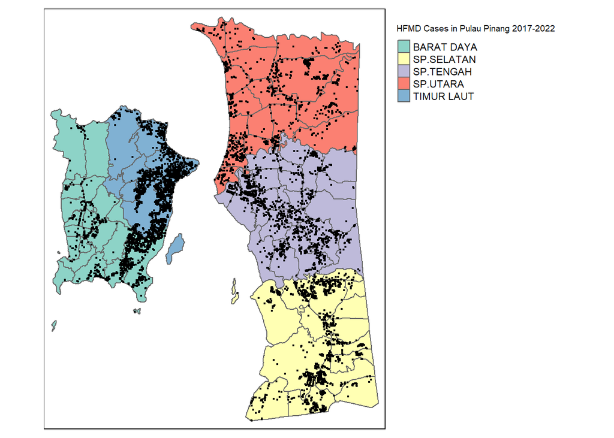

```r
tm_shape(Penang)+ tm_polygons("NAMA_DP", title = "HFMD Cases in Pulau Pinang 2017-2022",title.size = 10)+tm_shape(HFMD_overall) + tm_dots(col = "black")+ tm_layout(legend.outside = TRUE)
```

# Plot Yearly HFMD Cases in Pulau Pinang

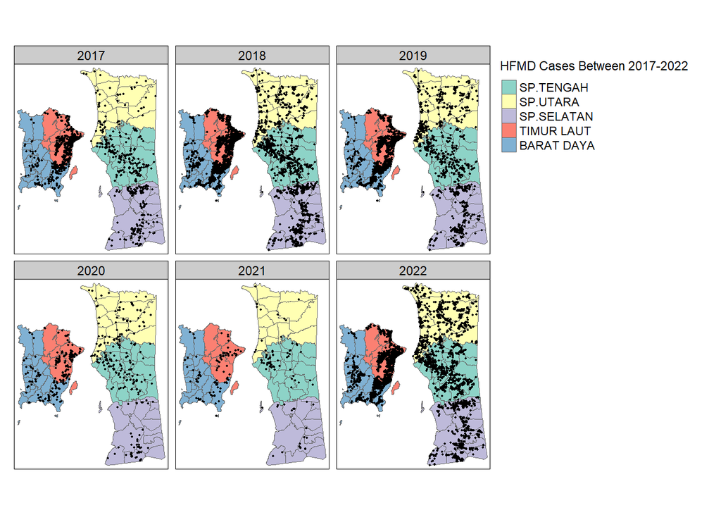

```r
tm_shape(Penang) +
  tm_polygons("NAMA_DP", title = "HFMD Cases Between 2017-2022",title.size = 1) +
  tm_shape(HFMD_overall) + tm_layout( legend.outside = TRUE) + tm_dots(col = "black", size = 0.03 ) + tm_facets("YEAR", nrow = 2, ncol = 3, as.layers = TRUE)
```

# Plot HFMD points(2017-2022) according to district

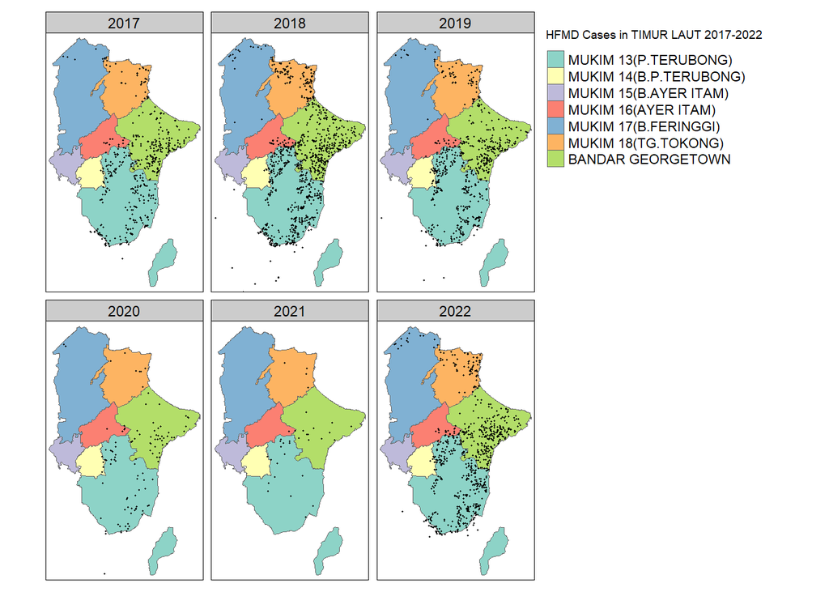

```r
tm_shape(Penang[Penang$NAMA_DP == "TIMUR LAUT",])+
  tm_polygons("NAMMUK",title = "HFMD Cases in TIMUR LAUT 2017-2022")+
  tm_shape(HFMD_overall[HFMD_overall$DAERAH == "TIMUR LAUT",])+tm_dots (col = "black")+tm_layout(legend.outside = TRUE) + tm_facets("YEAR", nrow = 2, ncol = 3, as.layers = TRUE)
```

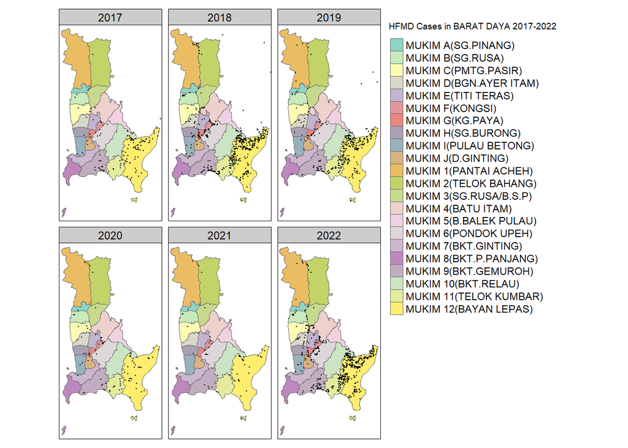

```r
tm_shape(Penang[Penang$NAMA_DP == "BARAT DAYA",])+
  tm_polygons("NAMMUK",title = "HFMD Cases in BARAT DAYA 2017-2022")+
  tm_shape(HFMD_overall[HFMD_overall$DAERAH == "BARAT DAYA",])+tm_dots (col = "black")+tm_layout(legend.outside = TRUE) + tm_facets("YEAR", nrow = 2, ncol = 3, as.layers = TRUE)
```

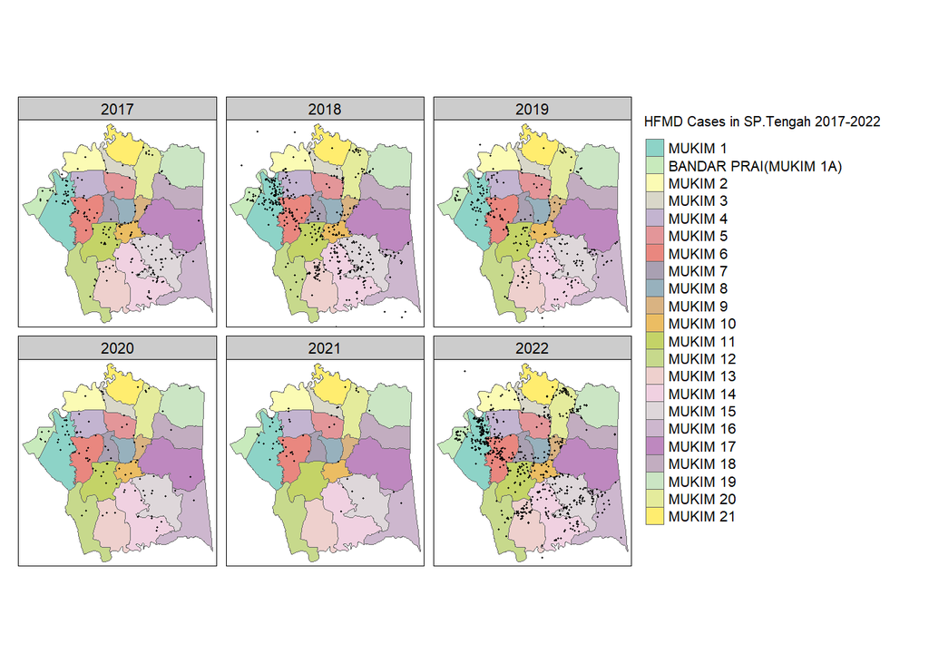

```r
tm_shape(Penang[Penang$NAMA_DP == "SP.TENGAH",])+
  tm_polygons("NAMMUK",title = "HFMD Cases in SP.Tengah 2017-2022")+
  tm_shape(HFMD_overall[HFMD_overall$DAERAH == "Seberang PERAI TENGAH",])+tm_dots (col = "black")+tm_layout(legend.outside = TRUE) + tm_facets("YEAR", nrow = 2, ncol = 3, as.layers = TRUE)
```

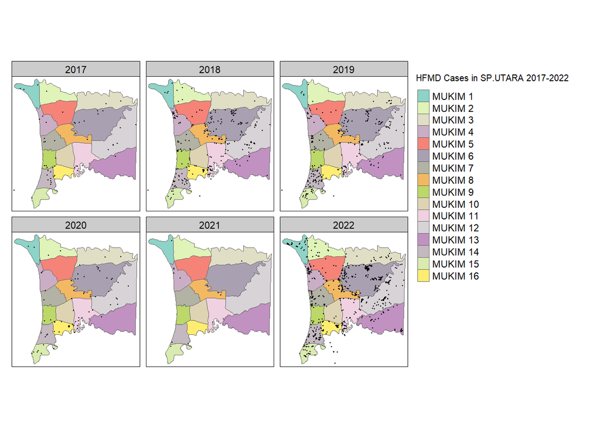

```r
tm_shape(Penang[Penang$NAMA_DP == "SP.UTARA",])+
  tm_polygons("NAMMUK",title = "HFMD Cases in SP.UTARA 2017-2022")+
  tm_shape(HFMD_overall[HFMD_overall$DAERAH == "SEBERANG PERAI UTARA",])+tm_dots (col = "black")+tm_layout(legend.outside = TRUE) + tm_facets("YEAR", nrow = 2, ncol = 3, as.layers = TRUE)
```

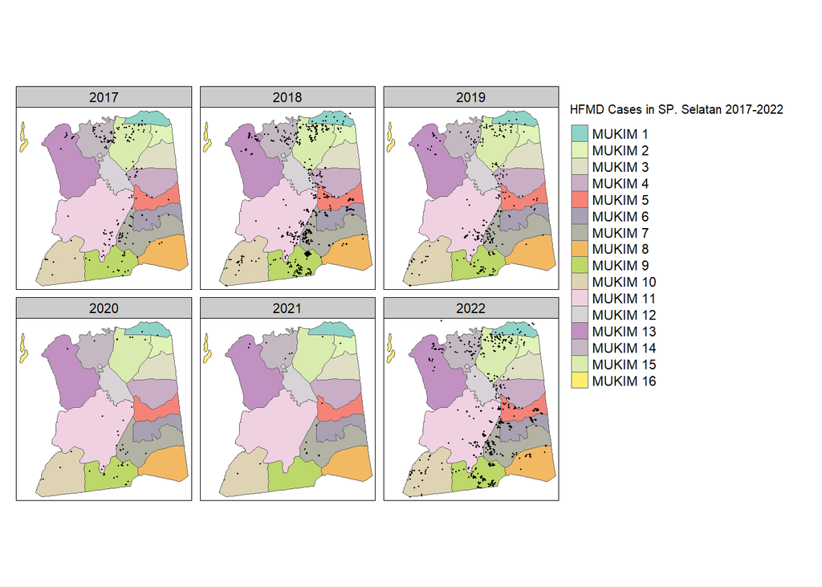

```r
tm_shape(Penang[Penang$NAMA_DP == "SP.SELATAN",])+
  tm_polygons("NAMMUK",title = "HFMD Cases in SP. Selatan 2017-2022")+
  tm_shape(HFMD_overall[HFMD_overall$DAERAH == "Seberang PERAI SELATAN",])+tm_dots (col = "black")+tm_layout(legend.outside = TRUE) + tm_facets("YEAR", nrow = 2, ncol = 3, as.layers = TRUE)
```

# Plot Monthly HFMD Cases in Pulau Pinang # 1.Convert “MONTH” variable to factor with ordered levels

```r
HFMD_overall$MONTH <- factor(HFMD_overall$MONTH,
                             levels = month.name,
                             ordered = TRUE)
```

#Plotting monthly HFMD Map

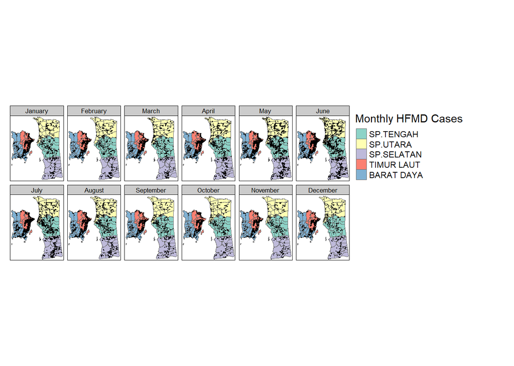

```r
tm_shape(Penang) +
  tm_polygons("NAMA_DP", title = "Monthly HFMD Cases",title.size = 1) +
  tm_shape(HFMD_overall) + tm_layout( legend.outside = TRUE) + tm_dots(col = "black", size = 0.03 ) + tm_facets("MONTH", nrow = 2, ncol = 6, as.layers = TRUE)
```

# Incidence of HFMD in Pulau Pinang # 1.Prepare Data # 2.count point in each Mukim

```r
Overall_Coor <- HFMD_overall [,c('geometry','YEAR','DAERAH')]
Overall_Coor <- na.omit(Overall_Coor)
```

```r
intersection_overall <- st_intersection(x=Penang,y=Overall_Coor)
count_HFMD_Mukim_Overall <- intersection_overall %>% count (YEAR,NAMA_DP,NAMMUK,PENDUDUK)
```

# 3.Load population data

```r
Gen_pop <- read_excel(here("Gen_Pop.xlsx"))
```

# 4.calculate incidence

```r
HFMD_Penang_Overall <- merge(count_HFMD_Mukim_Overall,Gen_pop, by = c("YEAR", "NAMA_DP","NAMMUK") , all=TRUE)
Overall_Incidence <- HFMD_Penang_Overall %>% mutate(Incidence_1000 = (n/PENDUDUK_L)*1000)
```

# 5. Merge Penang and HFMD Incidence Data

```r
HFMD_Penang_Overall_Incidence <- st_join(Penang, Overall_Incidence)
glimpse(HFMD_Penang_Overall_Incidence)
```

```
## Rows: 443
## Columns: 12
## $ NAMA_NG        <chr> "PULAU PINANG", "PULAU PINANG", "PULAU PINANG", "PULAU …
## $ NAMA_DP.x      <chr> "SP.TENGAH", "SP.TENGAH", "SP.TENGAH", "SP.TENGAH", "SP…
## $ NAMMUK.x       <chr> "MUKIM 1", "MUKIM 1", "MUKIM 1", "MUKIM 1", "MUKIM 1", …
## $ PENDUDUK.x     <dbl> 42653, 42653, 42653, 42653, 42653, 42653, 12644, 12644,…
## $ YEAR           <dbl> 2017, 2018, 2019, 2020, 2021, 2022, 2017, 2018, 2019, 2…
## $ NAMA_DP.y      <chr> "SP.TENGAH", "SP.TENGAH", "SP.TENGAH", "SP.TENGAH", "SP…
## $ NAMMUK.y       <chr> "MUKIM 1", "MUKIM 1", "MUKIM 1", "MUKIM 1", "MUKIM 1", …
## $ PENDUDUK.y     <dbl> 42653, 42653, 42653, 42653, 42653, 42653, 12644, 12644,…
## $ n              <int> 29, 128, 87, 26, 25, 194, 7, 22, 17, 5, 1, 41, 7, 13, 3…
## $ PENDUDUK_L     <dbl> 44300, 44100, 44000, 43800, 43800, 43800, 15900, 15900,…
## $ Incidence_1000 <dbl> 0.6546275, 2.9024943, 1.9772727, 0.5936073, 0.5707763, …
## $ geometry       <MULTIPOLYGON [m]> MULTIPOLYGON (((269049.6 59..., MULTIPOLYG…
```

# 6.Plot HFMD Incidence in Pulau Pinang (Overall)

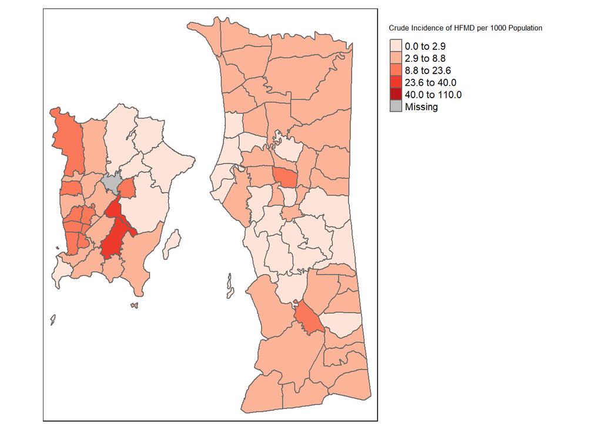

```r
tm_shape(Penang) + tm_borders(alpha=.6)  + tm_shape(HFMD_Penang_Overall_Incidence) + tm_polygons("Incidence_1000",style = "jenks", title = "Crude Incidence of HFMD per 1000 Population", palette = "Reds", range = c(0, 1000), breaks= 10)+tm_layout( legend.outside = TRUE)
```

# 7.Plot Yearly Incidence Rate of HFMD in Pulau Pinang

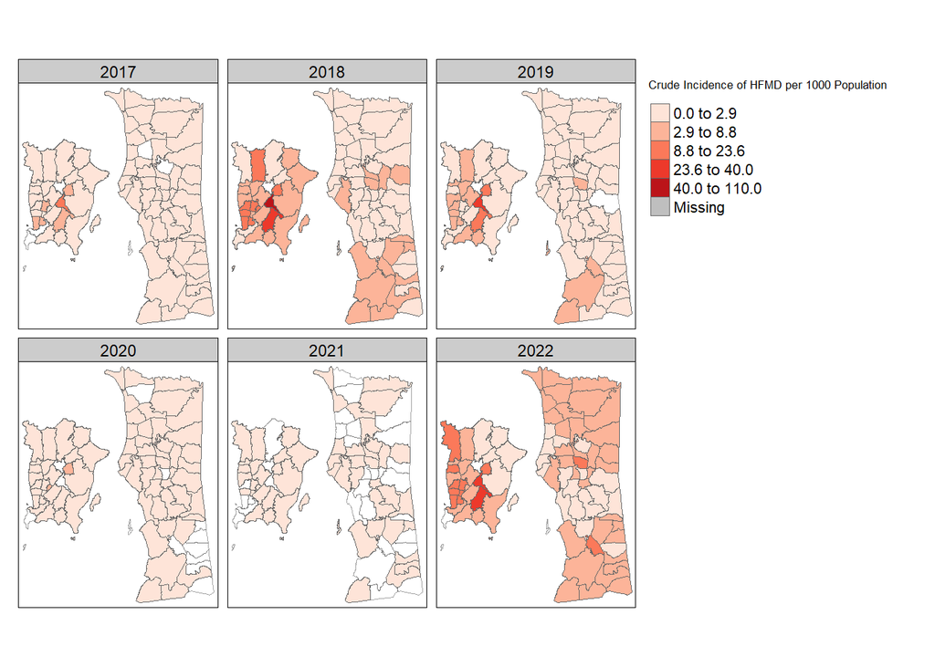

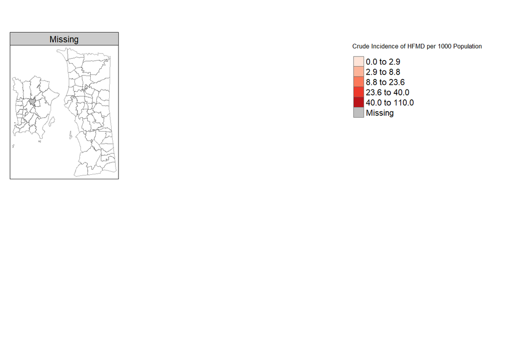

```r
tm_shape(Penang) + tm_borders(alpha=.6)  + tm_shape(HFMD_Penang_Overall_Incidence) + tm_polygons("Incidence_1000",style = "jenks", title = "Crude Incidence of HFMD per 1000 Population", palette = "Reds", range = c(0, 1000), breaks= 10) +  tm_facets("YEAR", nrow = 2, ncol = 3, as.layers = TRUE)
```

# 8. Yearly incidence according to district in Pulau Pinang # Timur Laut

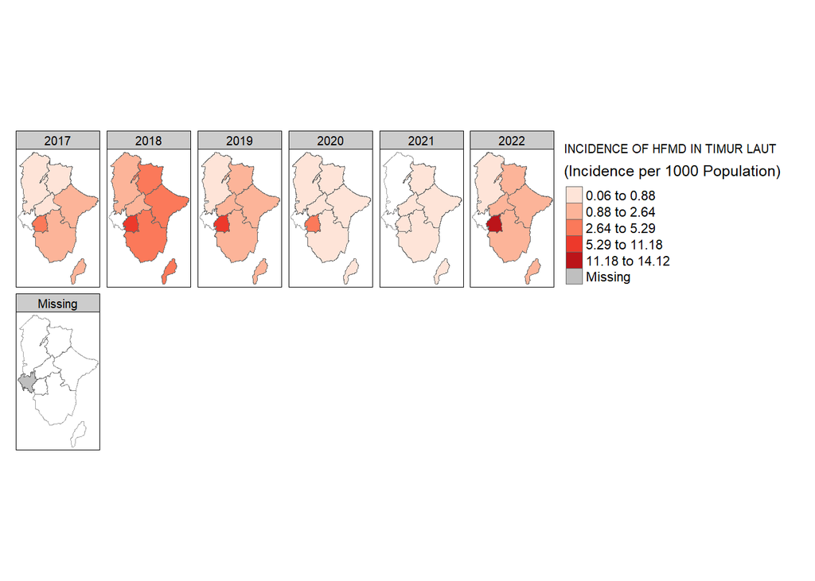

```r
tm_shape(Penang[Penang$NAMA_DP == "TIMUR LAUT", ])+ tm_borders(alpha=.6) +
tm_shape(HFMD_Penang_Overall_Incidence[HFMD_Penang_Overall_Incidence$ NAMA_DP.x== "TIMUR LAUT",])+tm_polygons("Incidence_1000",style = "jenks", title = "(Incidence per 1000 Population)", palette = "Reds") + tm_facets("YEAR", ncol = 6, as.layers = TRUE)+tm_layout(title = "INCIDENCE OF HFMD IN TIMUR LAUT",title.size=1)+  tm_layout(legend.outside = TRUE)
```

# Barat Daya

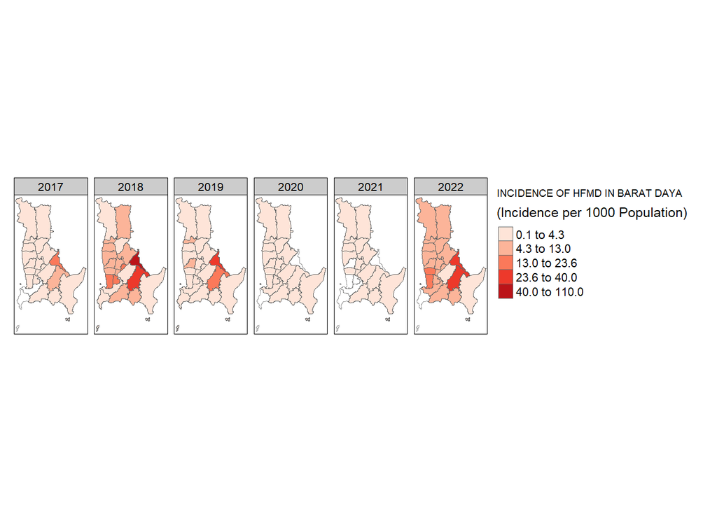

```r
tm_shape(Penang[Penang$NAMA_DP == "BARAT DAYA", ])+ tm_borders(alpha=.6) +
tm_shape(HFMD_Penang_Overall_Incidence[HFMD_Penang_Overall_Incidence$ NAMA_DP.x== "BARAT DAYA",])+tm_polygons("Incidence_1000",style = "jenks", title = "(Incidence per 1000 Population)", palette = "Reds") + tm_facets("YEAR", ncol = 6, as.layers = TRUE)+tm_layout(title = "INCIDENCE OF HFMD IN BARAT DAYA",title.size=1)+  tm_layout(legend.outside = TRUE)
```

# SP Tengah

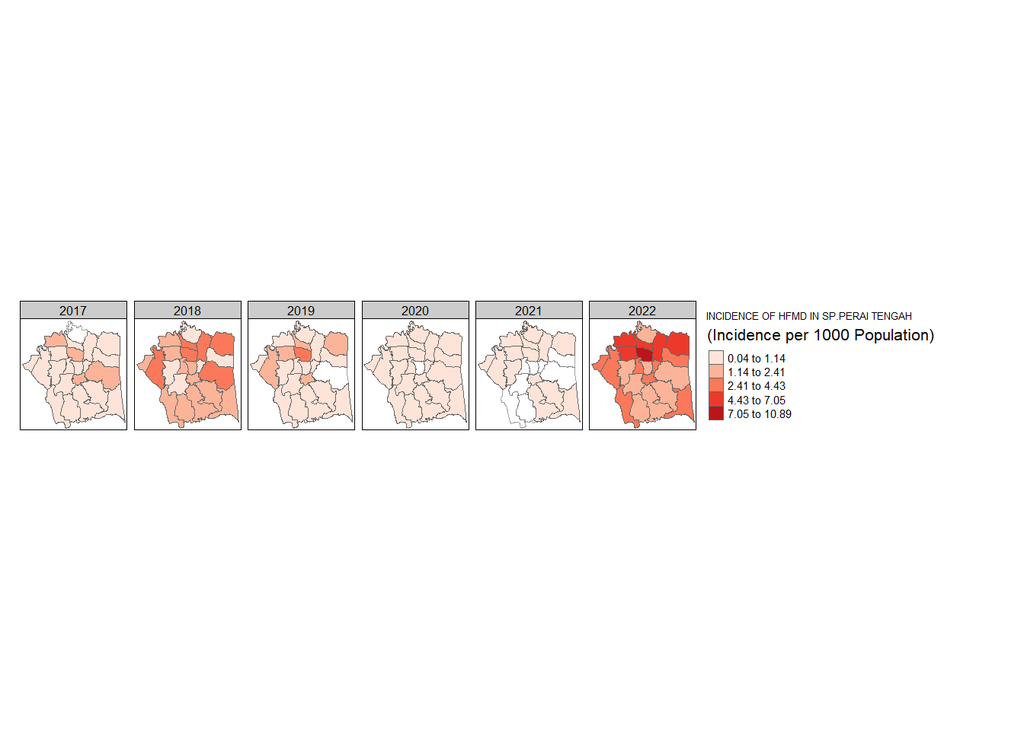

```r
tm_shape(Penang[Penang$NAMA_DP == "SP.TENGAH", ])+ tm_borders(alpha=.6) +
tm_shape(HFMD_Penang_Overall_Incidence[HFMD_Penang_Overall_Incidence$ NAMA_DP.x== "SP.TENGAH",])+tm_polygons("Incidence_1000",style = "jenks", title = "(Incidence per 1000 Population)", palette = "Reds") + tm_facets("YEAR", ncol = 6, as.layers = TRUE)+tm_layout(title = "INCIDENCE OF HFMD IN SP.PERAI TENGAH",title.size=1)+  tm_layout(legend.outside = TRUE)
```

# SP Utara

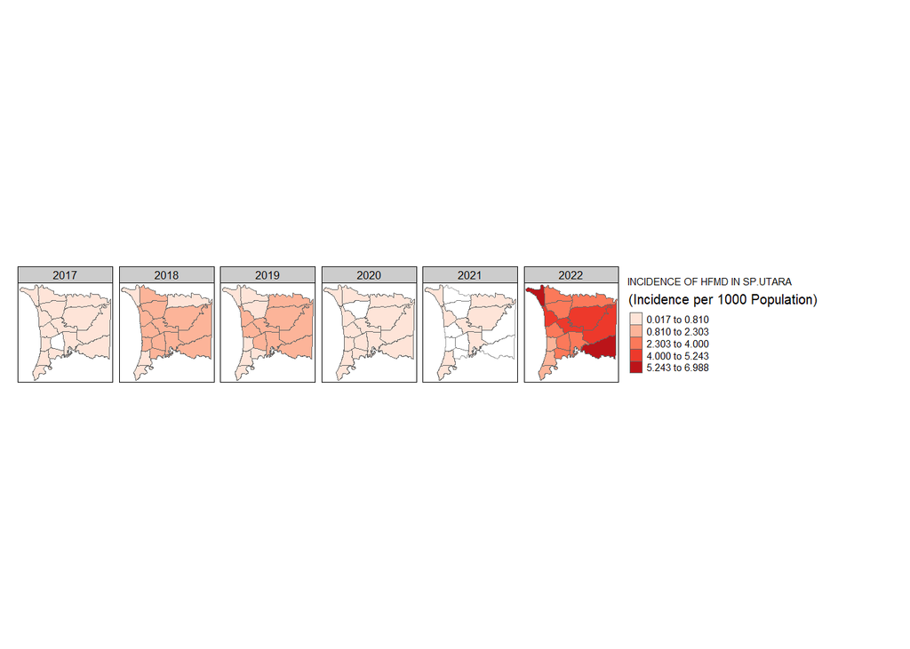

```r
tm_shape(Penang[Penang$NAMA_DP == "SP.UTARA", ])+ tm_borders(alpha=.6) +
tm_shape(HFMD_Penang_Overall_Incidence[HFMD_Penang_Overall_Incidence$ NAMA_DP.x== "SP.UTARA",])+tm_polygons("Incidence_1000",style = "jenks", title = "(Incidence per 1000 Population)", palette = "Reds") + tm_facets("YEAR", ncol = 6, as.layers = TRUE)+tm_layout(title = "INCIDENCE OF HFMD IN SP.UTARA",title.size=1)+  tm_layout(legend.outside = TRUE)
```

# SP Selatan

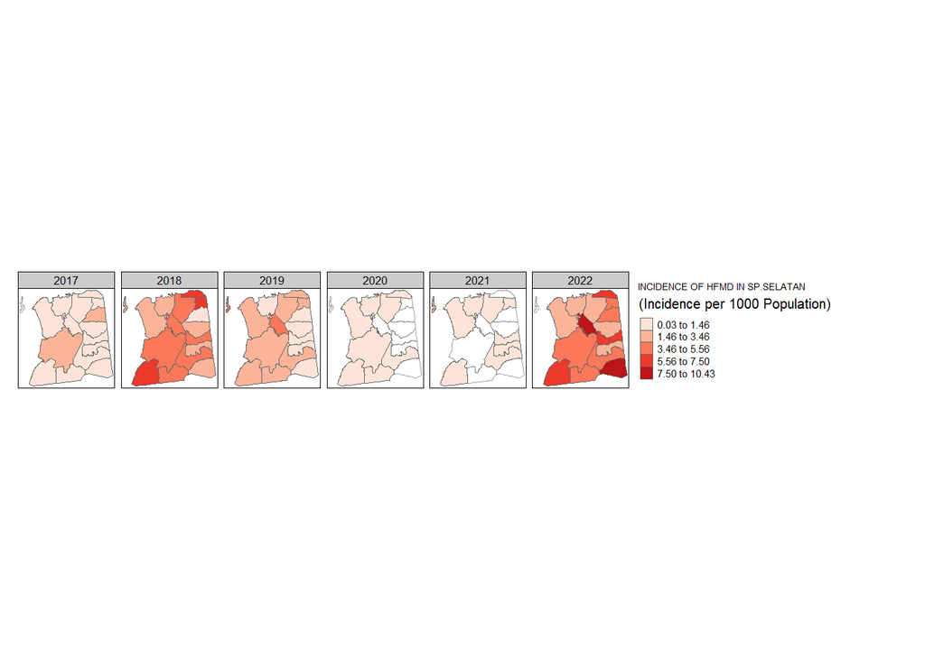

```r
tm_shape(Penang[Penang$NAMA_DP == "SP.SELATAN", ])+ tm_borders(alpha=.6) +
tm_shape(HFMD_Penang_Overall_Incidence[HFMD_Penang_Overall_Incidence$ NAMA_DP.x== "SP.SELATAN",])+tm_polygons("Incidence_1000",style = "jenks", title = "(Incidence per 1000 Population)", palette = "Reds") + tm_facets("YEAR", ncol = 6, as.layers = TRUE)+tm_layout(title = "INCIDENCE OF HFMD IN SP.SELATAN",title.size=1)+  tm_layout(legend.outside = TRUE)
```

# Density Based Analysis using Kernel Density Estimates (KDE) # Rescale and load point feature into Penang.owin #Move coordinate to first column

```r
HFMD_overall <- HFMD_overall[, c("geometry", names(HFMD_overall)[-which(names(HFMD_overall) == "geometry")])]
```

#Create owin data for Penang

```r
Penang.owin <- as.owin(Penang)
Penang.owin.km <- rescale(Penang.owin, 1000)
```

#Load point feature shapefile into Penang.owin

```r
HFMD_overall.ppp  <- as.ppp(HFMD_overall)
marks(HFMD_overall.ppp) <- NULL
HFMD_overall.ppp <- rescale(HFMD_overall.ppp, 1000,"km")
Window(HFMD_overall.ppp) <- Penang.owin.km
```

#Kernel Density Estimates (KDE) Pulau Pinang

```r
HFMD_overall.density <- density(HFMD_overall.ppp, sigma=1)
data.class(HFMD_overall.density)
```

```
## [1] "im"
```

#Rasterize the KDE image using package raster

```r
library(raster)
library(viridis)
library(leaflet)
```

```r
HFMD_overall.density.raster <- raster(HFMD_overall.density)
```

```r
xmin= 243501.5
xmax= 285076.2
ymin= 567201.1
ymax= 618503.2
```

#2.grab the cols and rows for the raster using @ncols and @nrows

```r
HFMD_overall.density.raster @ncols
```

```
## [1] 128
```

```r
HFMD_overall.density.raster @nrows
```

```
## [1] 128
```

#3.create a raster extend class

```r
rasExt <- extent(xmin,xmax,ymin,ymax)
rasExt
```

```
## class      : Extent
## xmin       : 243501.5
## xmax       : 285076.2
## ymin       : 567201.1
## ymax       : 618503.2
```

#4.apply the extent to our KDE raster

```r
HFMD_overall.density.raster@extent <- rasExt
HFMD_overall.density.raster
```

```
## class      : RasterLayer
## dimensions : 128, 128, 16384  (nrow, ncol, ncell)
## resolution : 324.8023, 400.7977  (x, y)
## extent     : 243501.5, 285076.2, 567201.1, 618503.2  (xmin, xmax, ymin, ymax)
## crs        : NA
## source     : memory
## names      : layer
## values     : 1.916806e-09, 179.5096  (min, max)
```

```r
crs(HFMD_overall.density.raster) <- 3168
```

## Plot Intensity of HFMD in Pulau Pinang

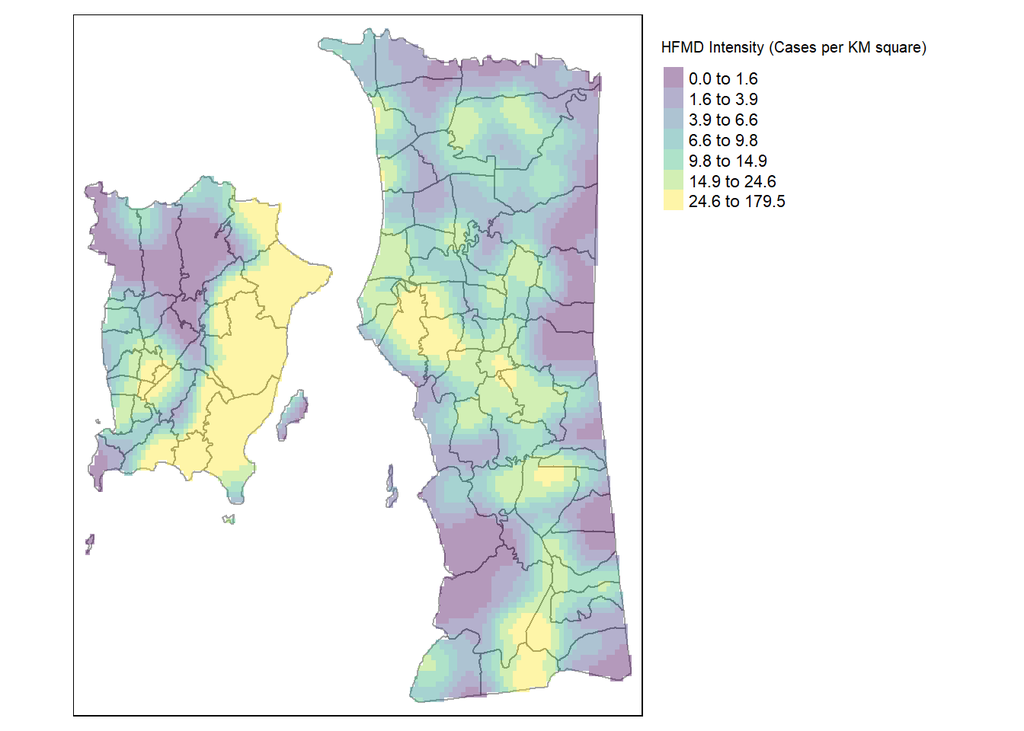

```r
tm_shape(Penang) +
  tm_borders(alpha=.6) +
  tm_shape(HFMD_overall.density.raster) +
  tm_raster(style = "quantile", n = 7 , palette = viridis(7, direction = 1), alpha = .4, title = "HFMD Intensity (Cases per KM square)") +
  tm_layout(legend.outside = TRUE)
```

## KDE intensity by YEAR #Convert “YEAR” variable to factor with ordered levels

```r
HFMD_overall$YEAR <- factor(HFMD_overall$YEAR,
                             ordered = TRUE)
```

#Plot Case vs YEAR

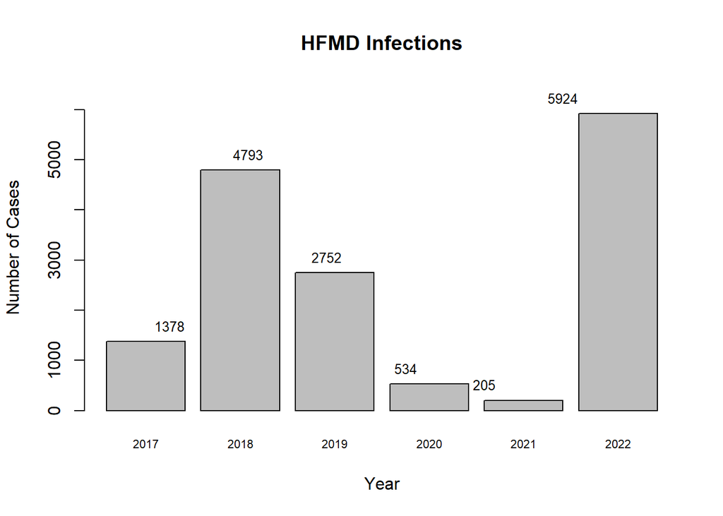

```r
counts <- table(HFMD_overall$YEAR)
barplot(counts, main = "HFMD Infections", xlab = "Year",
        ylab = "Number of Cases", cex.axis = 1, cex.lab = 1, cex.names = 0.7, ylim = c(0, 6500))
text(x = 1:length(counts), y = counts, labels = counts, pos = 3, cex = 0.8)
```

#KDE density for each year

```r
Coor_Year <- HFMD_overall[,c(1,3,4)]
Coor_Year  <- na.omit(Coor_Year )
```

```r
Y2017_coor <- subset(Coor_Year, YEAR=='2017')
Y2018_coor <- subset(Coor_Year, YEAR=='2018')
Y2019_coor <- subset(Coor_Year, YEAR=='2019')
Y2020_coor <- subset(Coor_Year, YEAR=='2020')
Y2021_coor <- subset(Coor_Year, YEAR=='2021')
Y2022_coor <- subset(Coor_Year, YEAR=='2022')
```

#Load a point feature shapefile into Penang.owin

```r
Y2017_coor.ppp  <- as.ppp(Y2017_coor)
marks(Y2017_coor.ppp ) <- NULL
Y2017_coor.ppp  <- rescale(Y2017_coor.ppp , 1000,"km")
Window(Y2017_coor.ppp ) <- Penang.owin.km
Y2018_coor.ppp  <- as.ppp(Y2018_coor)
marks(Y2018_coor.ppp ) <- NULL
Y2018_coor.ppp  <- rescale(Y2018_coor.ppp , 1000,"km")
Window(Y2018_coor.ppp ) <- Penang.owin.km
Y2019_coor.ppp  <- as.ppp(Y2019_coor)
marks(Y2019_coor.ppp ) <- NULL
Y2019_coor.ppp  <- rescale(Y2019_coor.ppp , 1000,"km")
Window(Y2019_coor.ppp ) <- Penang.owin.km
Y2020_coor.ppp  <- as.ppp(Y2020_coor)
marks(Y2017_coor.ppp ) <- NULL
Y2020_coor.ppp  <- rescale(Y2020_coor.ppp , 1000,"km")
Window(Y2020_coor.ppp ) <- Penang.owin.km
Y2021_coor.ppp  <- as.ppp(Y2021_coor)
marks(Y2021_coor.ppp ) <- NULL
Y2021_coor.ppp  <- rescale(Y2021_coor.ppp , 1000,"km")
Window(Y2021_coor.ppp ) <- Penang.owin.km
Y2022_coor.ppp  <- as.ppp(Y2022_coor)
marks(Y2022_coor.ppp ) <- NULL
Y2022_coor.ppp  <- rescale(Y2022_coor.ppp , 1000,"km")
Window(Y2022_coor.ppp ) <- Penang.owin.km
```

```r
Y2017.coor.density<- density(Y2017_coor.ppp, sigma=2)
Y2018.coor.density<- density(Y2018_coor.ppp, sigma=2)
Y2019.coor.density<- density(Y2019_coor.ppp, sigma=2)
Y2020.coor.density<- density(Y2020_coor.ppp, sigma=2)
Y2021.coor.density<- density(Y2021_coor.ppp, sigma=2)
Y2022.coor.density<- density(Y2022_coor.ppp, sigma=2)
```

#Plot KDE for Yearly Case

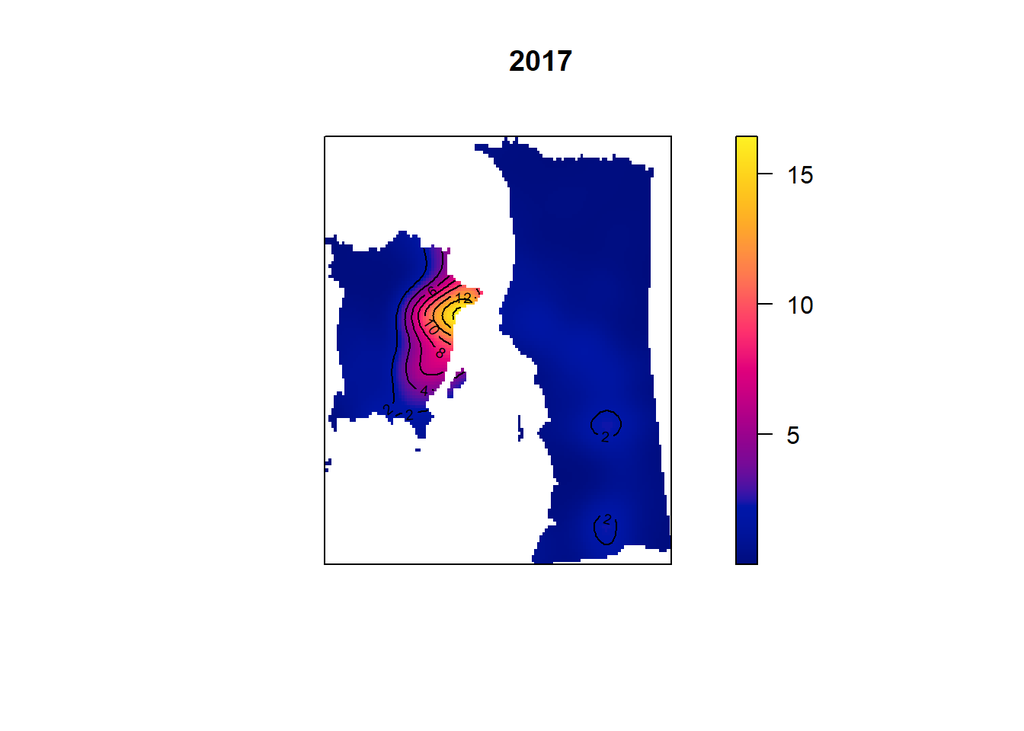

```r
plot(Y2017.coor.density, main = "2017", las = 1)
contour(Y2017.coor.density, add = TRUE)
```

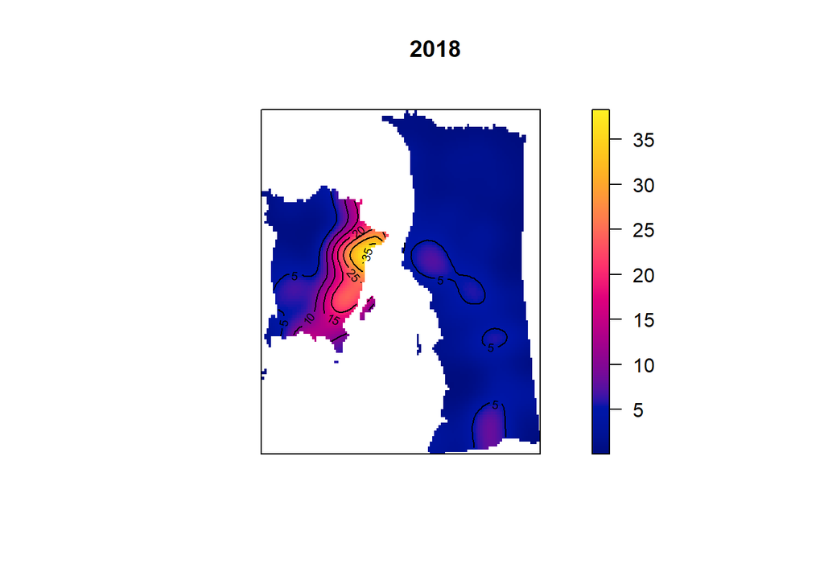

```r
plot(Y2018.coor.density, main = "2018", las = 1)
contour(Y2018.coor.density, add = TRUE)
```

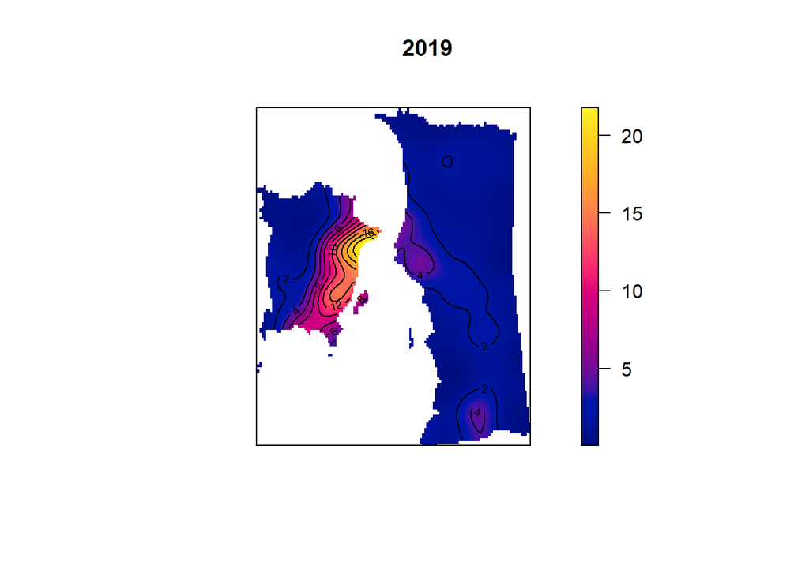

```r
plot(Y2019.coor.density, main = "2019", las = 1)
contour(Y2019.coor.density, add = TRUE)
```

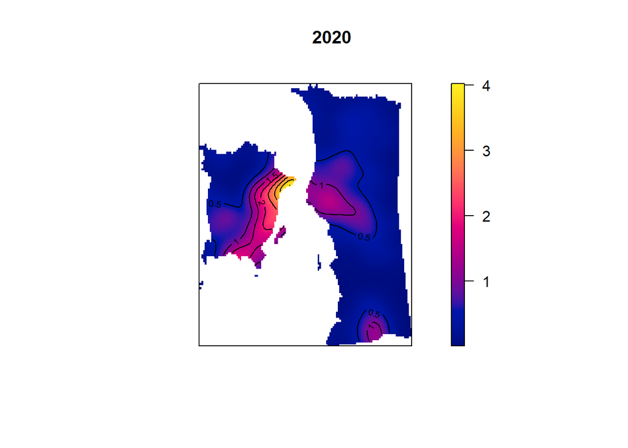

```r
plot(Y2020.coor.density, main = "2020", las = 1)
contour(Y2020.coor.density, add = TRUE)
```

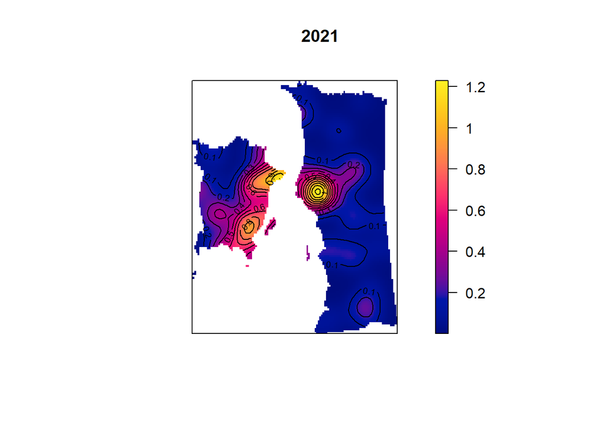

```r
plot(Y2021.coor.density, main = "2021", las = 1)
contour(Y2021.coor.density, add = TRUE)
```

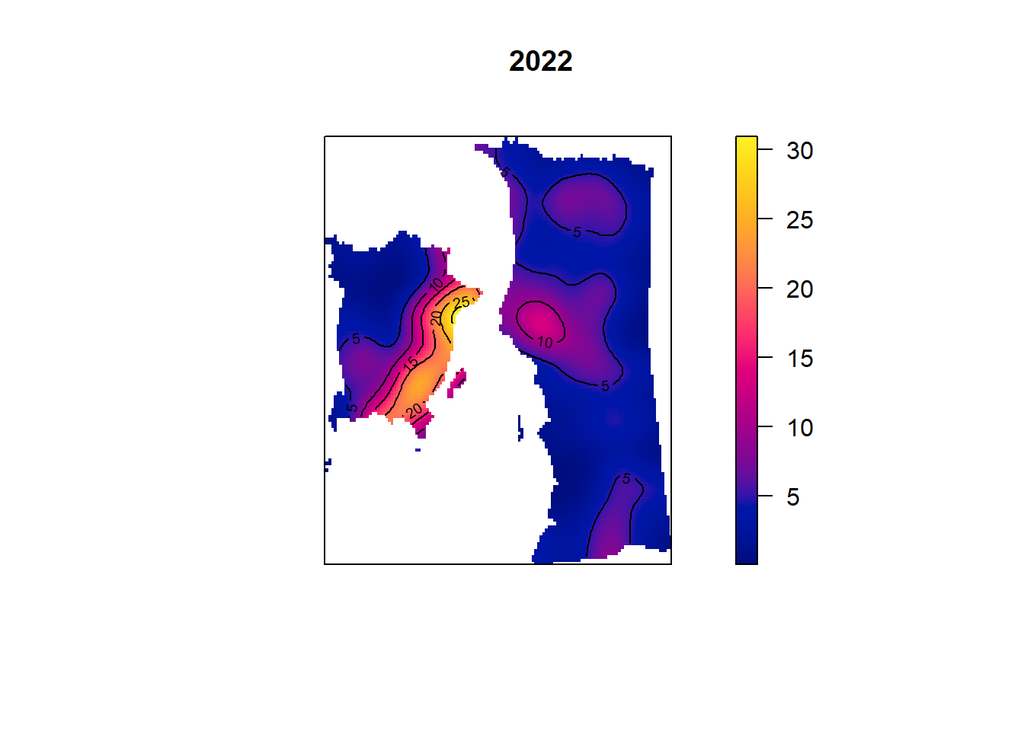

```r
plot(Y2022.coor.density, main = "2022", las = 1)
contour(Y2022.coor.density, add = TRUE)
```

# KDE intensity by Gender ## Select Gender and Coordinate from data

```r
Coor_Gender <- HFMD_overall[,c(1,8)]
Coor_Gender <- na.omit(Coor_Gender)
```

#Specified coordinate for male and female

```r
Male.coor <- subset(Coor_Gender, GENDER=='Lelaki')
Female.coor <- subset(Coor_Gender, GENDER=='Perempuan')
```

#Load a point feature shapefile into Penang.owin

```r
Male.coor.ppp  <- as.ppp(Male.coor)
marks(Male.coor.ppp ) <- NULL
Male.coor.ppp  <- rescale(Male.coor.ppp , 1000,"km")
Window(Male.coor.ppp ) <- Penang.owin.km
Female.coor.ppp  <- as.ppp(Female.coor)
marks(Female.coor.ppp ) <- NULL
Female.coor.ppp  <- rescale(Female.coor.ppp , 1000,"km")
Window(Female.coor.ppp ) <- Penang.owin.km
```

#Create Density function for gender

```r
Male.coor.density<- density(Male.coor.ppp , sigma=2)
Female.coor.density <- density(Female.coor.ppp , sigma=2)
```

#Plot KDE for gender

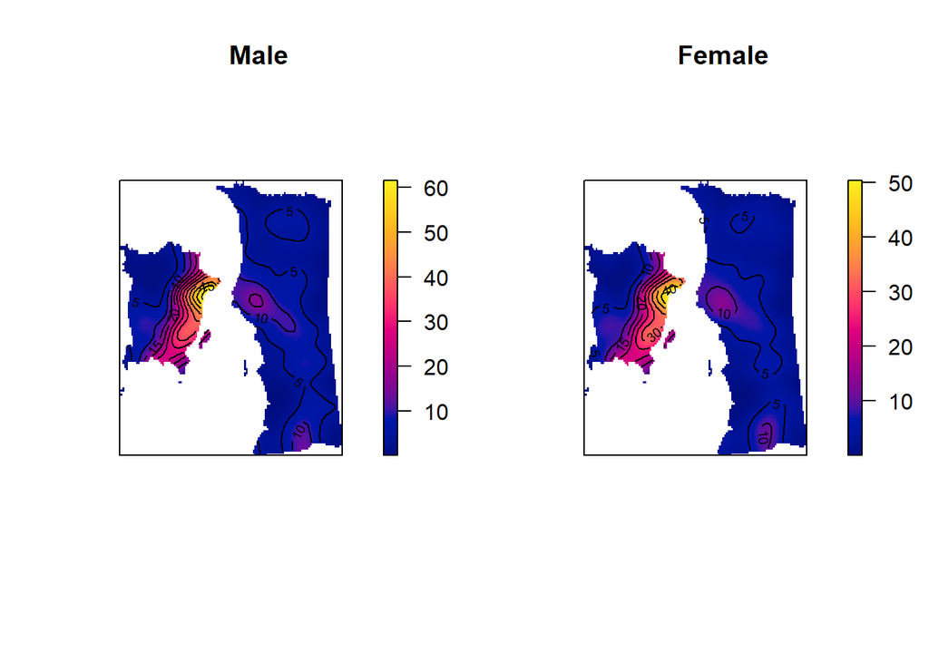

```r
par(mfrow=c(1,2))
plot(Male.coor.density, main = "Male", las = 1)
contour(Male.coor.density, add = TRUE)
plot(Female.coor.density, main = "Female", las = 1)
contour(Female.coor.density, add = TRUE)
```

#KDE intensity by Age Group #Categorise age of the cases

```r
HFMD_overall ["age_group"] = cut (HFMD_overall$AGE, c (0,5,10,Inf),c("0-4","5-10",">10"), include.lowest = TRUE)
```

#Plot Case vs Age Group

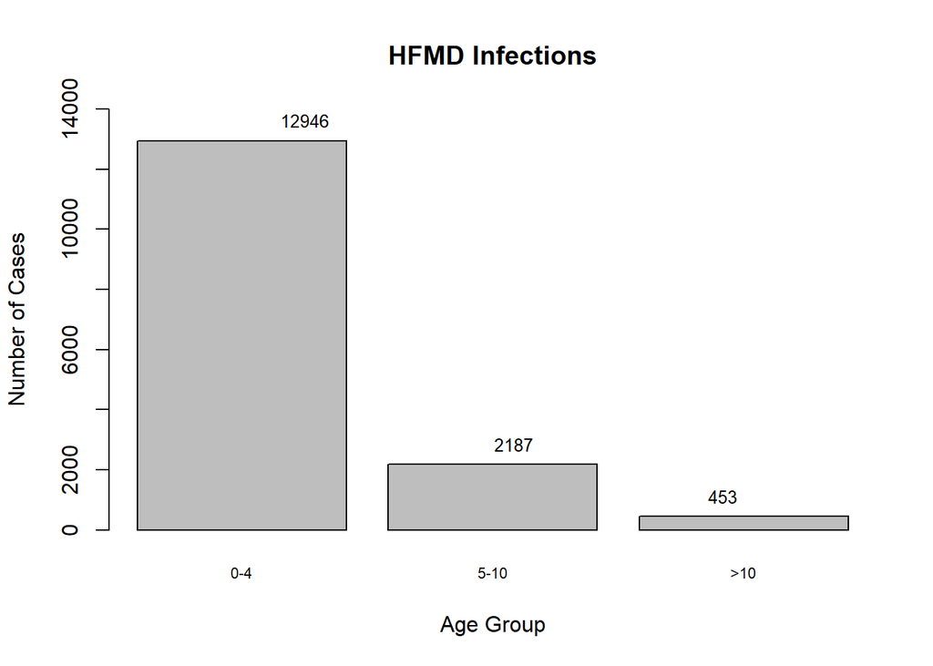

```r
counts <- table(HFMD_overall$age_group)
barplot(counts, main = "HFMD Infections", xlab = "Age Group",
        ylab = "Number of Cases", cex.axis = 1, cex.lab = 1, cex.names = 0.7, ylim = c(0, 14000))
text(x = 1:length(counts), y = counts, labels = counts, pos = 3, cex = 0.8)
```

#KDE density for each age group

```r
Coor_Age <- HFMD_overall[,c(1,13)]
Coor_Age  <- na.omit(Coor_Age )
```

#Specified coordinate for each age group

```r
Coor_Age_1 <- subset(Coor_Age, age_group =='0-4')
Coor_Age_2 <- subset(Coor_Age, age_group =='5-10')
Coor_Age_3 <- subset(Coor_Age, age_group =='>10')
```

#Load a point feature shapefile into Penang.owin

```r
Coor_Age_1.ppp  <- as.ppp(Coor_Age_1)
marks(Coor_Age_1.ppp ) <- NULL
Coor_Age_1.ppp  <- rescale(Coor_Age_1.ppp , 1000,"km")
Window(Coor_Age_1.ppp ) <- Penang.owin.km
Coor_Age_2.ppp  <- as.ppp(Coor_Age_2)
marks(Coor_Age_2.ppp ) <- NULL
Coor_Age_2.ppp  <- rescale(Coor_Age_2.ppp , 1000,"km")
Window(Coor_Age_2.ppp ) <- Penang.owin.km
Coor_Age_3.ppp  <- as.ppp(Coor_Age_3)
marks(Coor_Age_3.ppp ) <- NULL
Coor_Age_3.ppp  <- rescale(Coor_Age_3.ppp , 1000,"km")
Window(Coor_Age_3.ppp ) <- Penang.owin.km
```

#Create Density function for each age group

```r
Coor_Age_1.density<- density(Coor_Age_1.ppp, sigma=2)
Coor_Age_2.density<- density(Coor_Age_2.ppp, sigma=2)
Coor_Age_3.density<- density(Coor_Age_3.ppp, sigma=2)
```

#Plot KDE for each age group

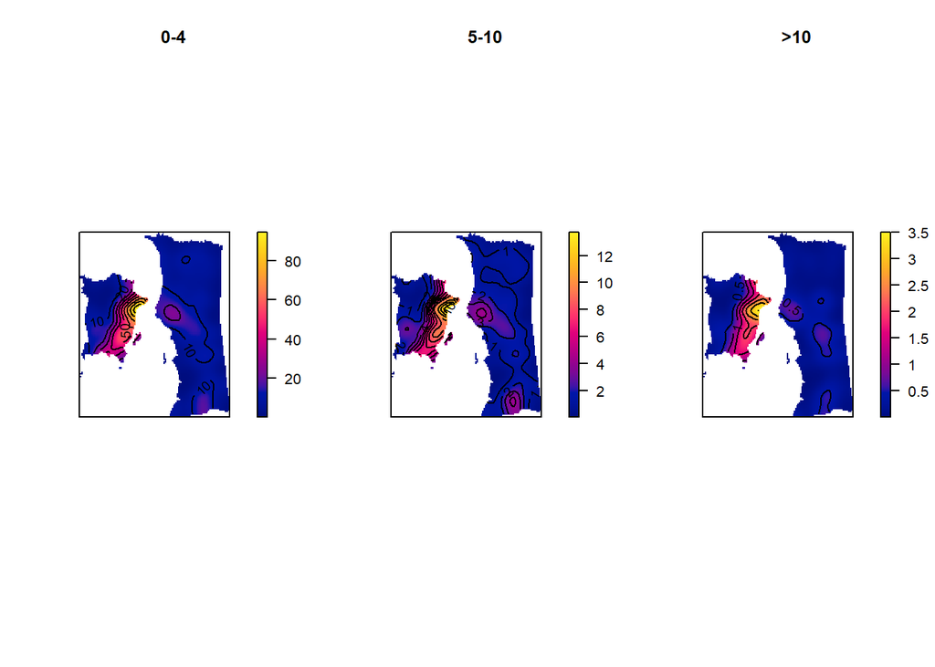

```r
par(mfrow=c(1,3))
plot(Coor_Age_1.density, main = "0-4", las = 1)
contour(Coor_Age_1.density, add = TRUE)
plot(Coor_Age_2.density, main = "5-10", las = 1)
contour(Coor_Age_2.density, add = TRUE)
plot(Coor_Age_3.density, main = ">10", las = 1)
contour(Coor_Age_3.density, add = TRUE)
```